# BikeSharingDemand

```r
library(readr)
library(tidyverse)
library(janitor)
library(skimr)
library(kableExtra)
library(patchwork)
library(caret)
library(randomForest)
```

```r
library(rpart)
library(rpart.plot)
```

```r
library(readr)      # Para leer el archivo csv
library(tidyverse)  # Para usar select, filter, mutate y pipes (%>%)
library(janitor)    # Para limpiar los nombres de las columnas rápidamente
library(skimr)      # Para el resumen estadístico detallado
library(kableExtra) # Para que nuestras tablas se vean ordenadas en el reporte
```

# 2. Descripción del Problema

Los sistemas de bicicletas compartidas se han convertido en una pieza fundamental de la movilidad urbana sostenible. Predecir con precisión la demanda diaria de alquiler permite a los operadores **optimizar la distribución de flotas**, planificar mantenimiento y mejorar la experiencia del usuario.

La pregunta central de este proyecto es:

> **¿Cuántas bicicletas serán alquiladas en un día determinado, considerando factores climáticos y temporales?**

Un modelo predictivo robusto permite:

- **Evitar desabastecimiento** en días de alta demanda (p. ej., días cálidos y secos).
- **Reducir costos operativos** redistribuyendo unidades en días de baja demanda.
- **Planificar estratégicamente** según estaciones del año, feriados y condiciones climáticas.

# Presentacion del dataset

```r
df <- read_csv("recursos/day.csv")
glimpse(df)
```

```
## Rows: 731
## Columns: 16
## $ instant    <dbl> 1, 2, 3, 4, 5, 6, 7, 8, 9, 10, 11, 12, 13, 14, 15, 16, 17, …
## $ dteday     <date> 2011-01-01, 2011-01-02, 2011-01-03, 2011-01-04, 2011-01-05…
## $ season     <dbl> 1, 1, 1, 1, 1, 1, 1, 1, 1, 1, 1, 1, 1, 1, 1, 1, 1, 1, 1, 1,…
## $ yr         <dbl> 0, 0, 0, 0, 0, 0, 0, 0, 0, 0, 0, 0, 0, 0, 0, 0, 0, 0, 0, 0,…
## $ mnth       <dbl> 1, 1, 1, 1, 1, 1, 1, 1, 1, 1, 1, 1, 1, 1, 1, 1, 1, 1, 1, 1,…
## $ holiday    <dbl> 0, 0, 0, 0, 0, 0, 0, 0, 0, 0, 0, 0, 0, 0, 0, 0, 1, 0, 0, 0,…
## $ weekday    <dbl> 6, 0, 1, 2, 3, 4, 5, 6, 0, 1, 2, 3, 4, 5, 6, 0, 1, 2, 3, 4,…
## $ workingday <dbl> 0, 0, 1, 1, 1, 1, 1, 0, 0, 1, 1, 1, 1, 1, 0, 0, 0, 1, 1, 1,…
## $ weathersit <dbl> 2, 2, 1, 1, 1, 1, 2, 2, 1, 1, 2, 1, 1, 1, 2, 1, 2, 2, 2, 2,…
## $ temp       <dbl> 0.3441670, 0.3634780, 0.1963640, 0.2000000, 0.2269570, 0.20…
## $ atemp      <dbl> 0.3636250, 0.3537390, 0.1894050, 0.2121220, 0.2292700, 0.23…
## $ hum        <dbl> 0.805833, 0.696087, 0.437273, 0.590435, 0.436957, 0.518261,…
## $ windspeed  <dbl> 0.1604460, 0.2485390, 0.2483090, 0.1602960, 0.1869000, 0.08…
## $ casual     <dbl> 331, 131, 120, 108, 82, 88, 148, 68, 54, 41, 43, 25, 38, 54…
## $ registered <dbl> 654, 670, 1229, 1454, 1518, 1518, 1362, 891, 768, 1280, 122…
## $ cnt        <dbl> 985, 801, 1349, 1562, 1600, 1606, 1510, 959, 822, 1321, 126…
```

```r
df <- as_tibble(df)
df
```

```
## # A tibble: 731 × 16
##    instant dteday     season    yr  mnth holiday weekday workingday weathersit
##      <dbl> <date>      <dbl> <dbl> <dbl>   <dbl>   <dbl>      <dbl>      <dbl>
##  1       1 2011-01-01      1     0     1       0       6          0          2
##  2       2 2011-01-02      1     0     1       0       0          0          2
##  3       3 2011-01-03      1     0     1       0       1          1          1
##  4       4 2011-01-04      1     0     1       0       2          1          1
##  5       5 2011-01-05      1     0     1       0       3          1          1
##  6       6 2011-01-06      1     0     1       0       4          1          1
##  7       7 2011-01-07      1     0     1       0       5          1          2
##  8       8 2011-01-08      1     0     1       0       6          0          2
##  9       9 2011-01-09      1     0     1       0       0          0          1
## 10      10 2011-01-10      1     0     1       0       1          1          1
## # ℹ 721 more rows
## # ℹ 7 more variables: temp <dbl>, atemp <dbl>, hum <dbl>, windspeed <dbl>,
## #   casual <dbl>, registered <dbl>, cnt <dbl>
```

> **Variable objetivo:** `cnt` — total de bicicletas alquiladas por día.

> **Nota:** `casual` y `registered` no deben usarse como predictores ya que su suma compone directamente `cnt`.

## Renombrar y tipificar columnas

```r
df_clean <- df %>%
  rename(
    fecha        = dteday,
    estacion     = season,
    anio         = yr,
    mes          = mnth,
    feriado      = holiday,
    dia_semana   = weekday,
    dia_laboral  = workingday,
    clima        = weathersit,
    total_rentas = cnt
  ) %>%
  mutate(
    fecha       = as.Date(fecha),
    estacion    = factor(estacion, levels = 1:4,
                         labels = c("Invierno", "Primavera", "Verano", "Otoño")),
    anio        = factor(anio, levels = 0:1, labels = c("2011", "2012")),
    mes         = factor(mes, levels = 1:12, labels = month.abb),
    feriado     = factor(feriado, levels = 0:1, labels = c("No", "Sí")),
    dia_semana  = factor(dia_semana, levels = 0:6,
                         labels = c("Dom", "Lun", "Mar", "Mié", "Jue", "Vie", "Sab")),
    dia_laboral = factor(dia_laboral, levels = 0:1, labels = c("No", "Sí")),
    clima       = factor(clima, levels = 1:4,
                         labels = c("Despejado", "Nublado", "Lluvia Ligera", "Tormenta")),
    tipo_dia    = ifelse(dia_laboral == "Sí", "Día Laboral", "Fin de Semana / Feriado"),
    pct_casual  = round((casual / total_rentas) * 100, 1)
  )

glimpse(df_clean)
```

```
## Rows: 731
## Columns: 18
## $ instant      <dbl> 1, 2, 3, 4, 5, 6, 7, 8, 9, 10, 11, 12, 13, 14, 15, 16, 17…
## $ fecha        <date> 2011-01-01, 2011-01-02, 2011-01-03, 2011-01-04, 2011-01-…
## $ estacion     <fct> Invierno, Invierno, Invierno, Invierno, Invierno, Inviern…
## $ anio         <fct> 2011, 2011, 2011, 2011, 2011, 2011, 2011, 2011, 2011, 201…
## $ mes          <fct> Jan, Jan, Jan, Jan, Jan, Jan, Jan, Jan, Jan, Jan, Jan, Ja…
## $ feriado      <fct> No, No, No, No, No, No, No, No, No, No, No, No, No, No, N…
## $ dia_semana   <fct> Sab, Dom, Lun, Mar, Mié, Jue, Vie, Sab, Dom, Lun, Mar, Mi…
## $ dia_laboral  <fct> No, No, Sí, Sí, Sí, Sí, Sí, No, No, Sí, Sí, Sí, Sí, Sí, N…
## $ clima        <fct> Nublado, Nublado, Despejado, Despejado, Despejado, Despej…
## $ temp         <dbl> 0.3441670, 0.3634780, 0.1963640, 0.2000000, 0.2269570, 0.…
## $ atemp        <dbl> 0.3636250, 0.3537390, 0.1894050, 0.2121220, 0.2292700, 0.…
## $ hum          <dbl> 0.805833, 0.696087, 0.437273, 0.590435, 0.436957, 0.51826…
## $ windspeed    <dbl> 0.1604460, 0.2485390, 0.2483090, 0.1602960, 0.1869000, 0.…
## $ casual       <dbl> 331, 131, 120, 108, 82, 88, 148, 68, 54, 41, 43, 25, 38, …
## $ registered   <dbl> 654, 670, 1229, 1454, 1518, 1518, 1362, 891, 768, 1280, 1…
## $ total_rentas <dbl> 985, 801, 1349, 1562, 1600, 1606, 1510, 959, 822, 1321, 1…
## $ tipo_dia     <chr> "Fin de Semana / Feriado", "Fin de Semana / Feriado", "Dí…
## $ pct_casual   <dbl> 33.6, 16.4, 8.9, 6.9, 5.1, 5.5, 9.8, 7.1, 6.6, 3.1, 3.4, …
```

## Verificación de valores faltantes

```r
na_summary <- df_clean %>%
  summarise(across(everything(), ~ sum(is.na(.)))) %>%
  pivot_longer(everything(), names_to = "Variable", values_to = "NA_Count") %>%
  filter(NA_Count > 0)

if (nrow(na_summary) == 0) {
  cat("No se encontraron valores faltantes en ninguna variable.\n")
} else {
  na_summary %>%
    kable() %>%
    kable_styling(bootstrap_options = c("striped"), full_width = FALSE)
}
```

```
## No se encontraron valores faltantes en ninguna variable.
```

## Resumen estadístico

```r
df_clean %>%
  select(temp, atemp, hum, windspeed, casual, registered, total_rentas) %>%
  skim() %>%
  kable() %>%
  kable_styling(bootstrap_options = c("striped", "hover", "condensed"),
                full_width = FALSE, font_size = 12)
```

| skim_type | skim_variable | n_missing | complete_rate | numeric.mean | numeric.sd | numeric.p0 | numeric.p25 | numeric.p50 | numeric.p75 | numeric.p100 | numeric.hist |
| --- | --- | --- | --- | --- | --- | --- | --- | --- | --- | --- | --- |
| numeric | temp | 0 | 1 | 0.4953848 | 0.1830510 | 0.0591304 | 0.3370835 | 0.498333 | 0.6554165 | 0.861667 | ▂▇▇▇▅ |
| numeric | atemp | 0 | 1 | 0.4743540 | 0.1629612 | 0.0790696 | 0.3378425 | 0.486733 | 0.6086020 | 0.840896 | ▂▇▆▇▂ |
| numeric | hum | 0 | 1 | 0.6278941 | 0.1424291 | 0.0000000 | 0.5200000 | 0.626667 | 0.7302085 | 0.972500 | ▁▁▆▇▂ |
| numeric | windspeed | 0 | 1 | 0.1904862 | 0.0774979 | 0.0223917 | 0.1349500 | 0.180975 | 0.2332145 | 0.507463 | ▃▇▅▁▁ |
| numeric | casual | 0 | 1 | 848.1764706 | 686.6224883 | 2.0000000 | 315.5000000 | 713.000000 | 1096.0000000 | 3410.000000 | ▇▆▂▁▁ |
| numeric | registered | 0 | 1 | 3656.1723666 | 1560.2563770 | 20.0000000 | 2497.0000000 | 3662.000000 | 4776.5000000 | 6946.000000 | ▂▅▇▅▃ |
| numeric | total_rentas | 0 | 1 | 4504.3488372 | 1937.2114516 | 22.0000000 | 3152.0000000 | 4548.000000 | 5956.0000000 | 8714.000000 | ▂▅▇▅▃ |

# Análisis Exploratorio de Datos (EDA)

## Distribución de la variable objetivo (`total_rentas`)

```r
stats_cnt <- df_clean %>%
  summarise(
    Media   = round(mean(total_rentas)),
    Mediana = median(total_rentas),
    SD      = round(sd(total_rentas)),
    Min     = min(total_rentas),
    Max     = max(total_rentas),
    Q1      = quantile(total_rentas, 0.25),
    Q3      = quantile(total_rentas, 0.75)
  )

stats_cnt %>%
  kable(caption = "Estadísticas descriptivas de la demanda diaria") %>%
  kable_styling(bootstrap_options = c("striped"), full_width = FALSE)
```

Estadísticas descriptivas de la demanda diaria

| Media | Mediana | SD | Min | Max | Q1 | Q3 |
| --- | --- | --- | --- | --- | --- | --- |
| 4504 | 4548 | 1937 | 22 | 8714 | 3152 | 5956 |

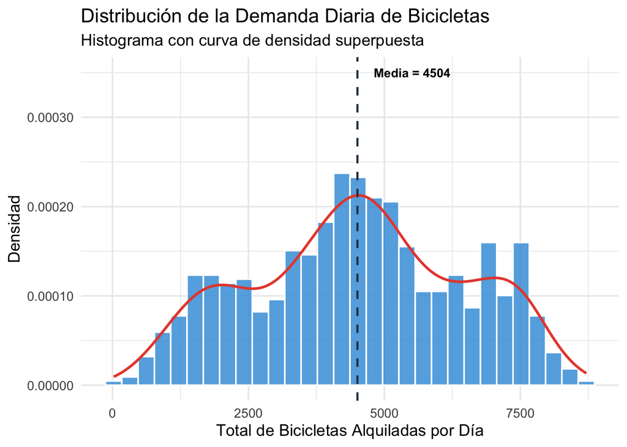

```r
ggplot(df_clean, aes(x = total_rentas)) +
  geom_histogram(aes(y = after_stat(density)),
                 bins = 30, fill = "#3498db", color = "white", alpha = 0.8) +
  geom_density(color = "#e74c3c", linewidth = 1) +
  geom_vline(xintercept = mean(df_clean$total_rentas),
             linetype = "dashed", color = "#2c3e50", linewidth = 0.8) +
  annotate("text",
           x = mean(df_clean$total_rentas) + 300,
           y = 0.00035,
           label = paste0("Media = ", round(mean(df_clean$total_rentas))),
           hjust = 0, fontface = "bold", size = 3.5) +
  scale_y_continuous(labels = scales::label_number(accuracy = 0.00001)) +
  labs(
    title = "Distribución de la Demanda Diaria de Bicicletas",
    subtitle = "Histograma con curva de densidad superpuesta",
    x = "Total de Bicicletas Alquiladas por Día",
    y = "Densidad"
  ) +
  theme_minimal(base_size = 13)
```

La distribución muestra una forma aproximadamente **normal con leve asimetría negativa**, lo que sugiere que la mayoría de los días tienen demanda moderada-alta, con algunos días atípicos de baja demanda (posiblemente asociados a condiciones climáticas adversas).

## Detección de Outliers

```r
p_box <- ggplot(df_clean, aes(y = total_rentas)) +
  geom_boxplot(fill = "#3498db", alpha = 0.6, width = 0.4) +
  labs(title = "Boxplot de Demanda Diaria", y = "Total Rentas") +
  theme_minimal(base_size = 13) +
  theme(axis.text.x = element_blank(), axis.ticks.x = element_blank())

Q1 <- quantile(df_clean$total_rentas, 0.25)
Q3 <- quantile(df_clean$total_rentas, 0.75)
IQR_val <- Q3 - Q1
lower <- Q1 - 1.5 * IQR_val
upper <- Q3 + 1.5 * IQR_val

outliers <- df_clean %>%
  filter(total_rentas < lower | total_rentas > upper)

cat(paste0("Rango IQR: [", round(lower), ", ", round(upper), "]\n"))
```

```
## Rango IQR: [-1054, 10162]
```

```r
cat(paste0("Outliers detectados: ", nrow(outliers), " días\n"))
```

```
## Outliers detectados: 0 días
```

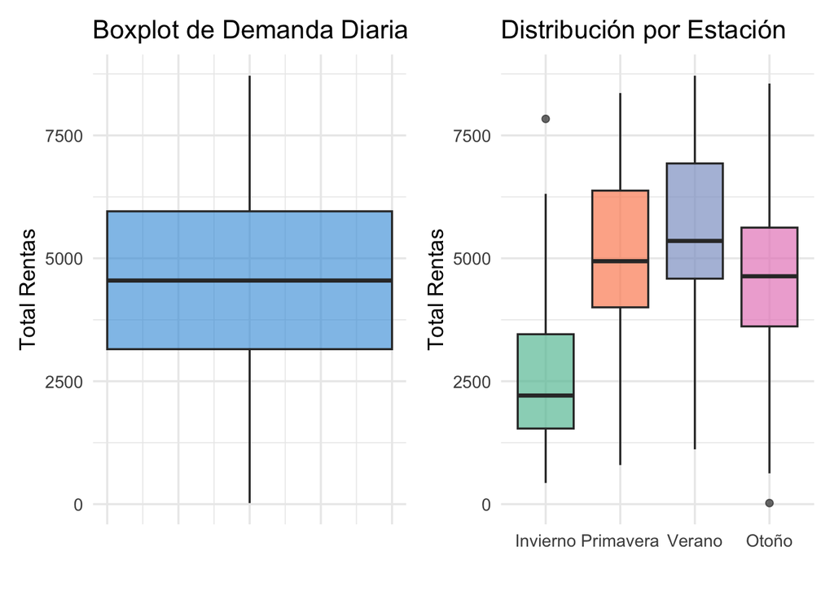

```r
p_box_season <- ggplot(df_clean, aes(x = estacion, y = total_rentas, fill = estacion)) +
  geom_boxplot(alpha = 0.7) +
  scale_fill_brewer(palette = "Set2") +
  labs(title = "Distribución por Estación", x = "", y = "Total Rentas") +
  theme_minimal(base_size = 13) +
  theme(legend.position = "none")

p_box | p_box_season
```

```r
if (nrow(outliers) > 0) {
  outliers %>%
    select(fecha, estacion, clima, temp, hum, windspeed, total_rentas) %>%
    arrange(total_rentas) %>%
    kable(caption = "Días identificados como outliers") %>%
    kable_styling(bootstrap_options = c("striped", "hover"), full_width = FALSE)
}
```

## Patrones Temporales

### Evolucion temporal de la demanda

Se utiliza LOESS(LOcally Estimated Scatterplot Smoothing) para la reduccion de ruido y revelar la tendencia en la demanda

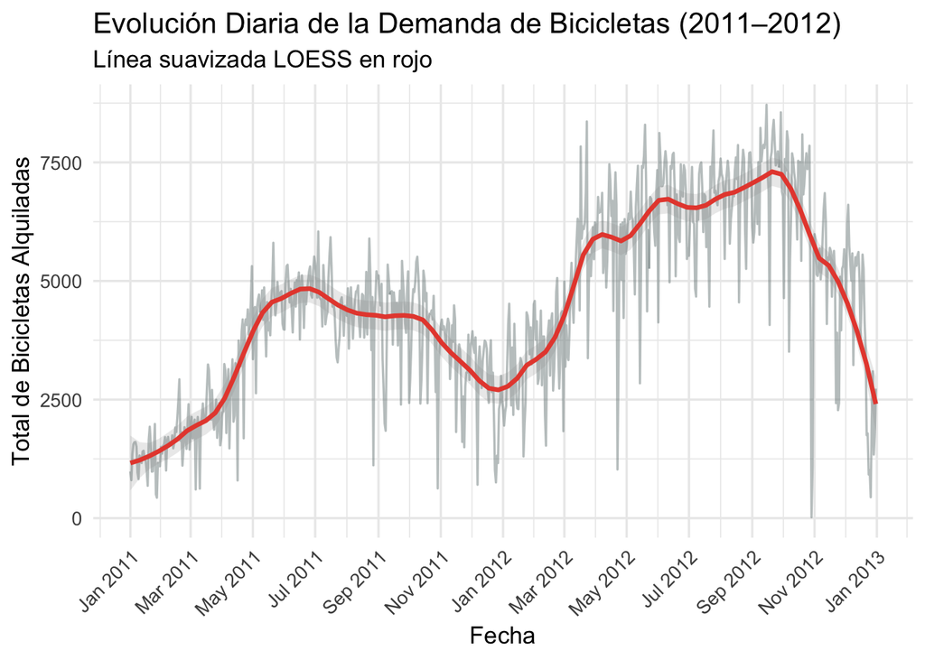

```r
ggplot(df_clean, aes(x = fecha, y = total_rentas)) +
  geom_line(color = "#7f8c8d", alpha = 0.5) +
  geom_smooth(method = "loess", span = 0.15, color = "#e74c3c", se = TRUE, alpha = 0.2) +
  labs(
    title = "Evolución Diaria de la Demanda de Bicicletas (2011–2012)",
    subtitle = "Línea suavizada LOESS en rojo",
    x = "Fecha",
    y = "Total de Bicicletas Alquiladas"
  ) +
  scale_x_date(date_labels = "%b %Y", date_breaks = "2 months") +
  theme_minimal(base_size = 13) +
  theme(axis.text.x = element_text(angle = 45, hjust = 1))
```

Se observa una **clara estacionalidad anual**: la demanda crece de primavera a verano/otoño y disminuye en invierno. Además, hay una **tendencia creciente** entre 2011 y 2012, posiblemente por mayor adopción del sistema.

visualizaciones

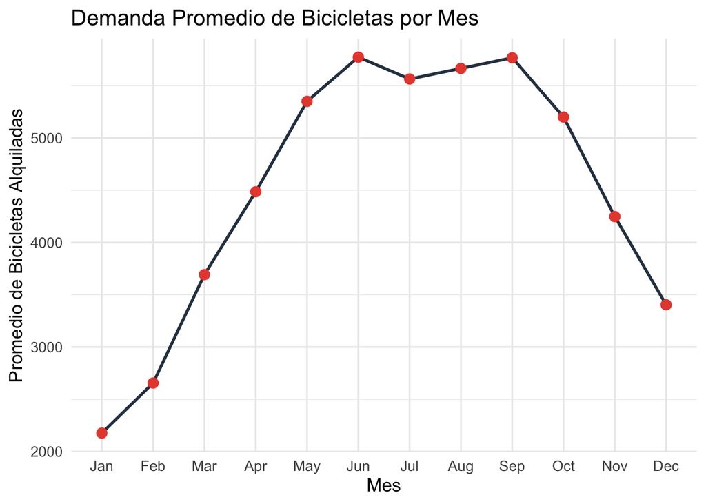

```r
demanda_mes <- df_clean %>%
  group_by(mes) %>%
  summarise(
    promedio_rentas = mean(total_rentas),
    .groups = "drop"
  )

ggplot(demanda_mes, aes(x = mes, y = promedio_rentas, group = 1)) +
  geom_line(color = "#2c3e50", linewidth = 1) +
  geom_point(size = 3, color = "#e74c3c") +
  labs(
    title = "Demanda Promedio de Bicicletas por Mes",
    x = "Mes",
    y = "Promedio de Bicicletas Alquiladas"
  ) +
  theme_minimal(base_size = 13)
```

Se puede observar que entre los meses de mayo a septiembre es cuando hay mayor demanda de bicicletas, se interpreta la razón de este suceso por e hecho de la entrada del verano(mayo), el verano (junio- agosto), y la salida del verano(septiembre), y ya en meses o epocas más frías la demanda disminuye

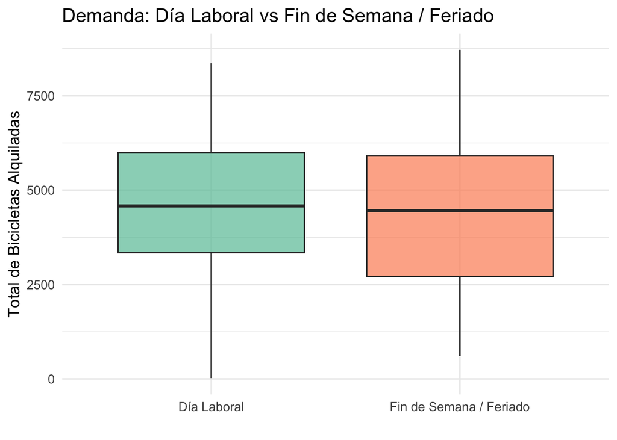

```r
demanda_tipo_dia <- df_clean %>%
  group_by(tipo_dia) %>%
  summarise(
    promedio_rentas = mean(total_rentas),
    .groups = "drop"
  )

ggplot(df_clean, aes(x = tipo_dia, y = total_rentas, fill = tipo_dia)) +
  geom_boxplot(alpha = 0.7) +
  scale_fill_brewer(palette = "Set2") +
  labs(
    title = "Demanda: Día Laboral vs Fin de Semana / Feriado",
    x = "",
    y = "Total de Bicicletas Alquiladas"
  ) +
  theme_minimal(base_size = 13) +
  theme(legend.position = "none")
```

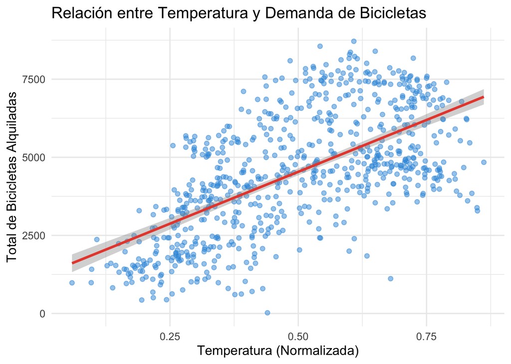

```r
ggplot(df_clean, aes(x = temp, y = total_rentas)) +
  geom_point(alpha = 0.5, color = "#3498db") +
  geom_smooth(method = "lm", color = "#e74c3c", se = TRUE) +
  labs(
    title = "Relación entre Temperatura y Demanda de Bicicletas",
    x = "Temperatura (Normalizada)",
    y = "Total de Bicicletas Alquiladas"
  ) +
  theme_minimal(base_size = 13)
```

Se puede observar que la temperatura afecta la cantidad de bicicletas alquiladas, ya que se puede observar una mayor cantidad de alquileres mientras más alta sea la temperatura

# Preparación del dataset

## Limpieza final

Antes de construir cualquier modelo es necesario dejar el dataframe libre de columnas redundantes, registros duplicados y variables que filtren información de la variable objetivo.

```r
# 1. Eliminar columnas que no aportan al modelo
#    - instant : índice secuencial sin valor predictivo
#    - casual / registered : su suma ES la variable objetivo (fuga de datos)
#    - pct_casual : derivada de casual y total_rentas (también fuga)
df_model <- df_clean %>%
  select(-instant, -casual, -registered, -pct_casual)

cat("Dimensiones después de eliminar columnas redundantes:",
    nrow(df_model), "filas ×", ncol(df_model), "columnas\n")
```

```
## Dimensiones después de eliminar columnas redundantes: 731 filas × 14 columnas
```

```r
# 2. Verificar y eliminar registros duplicados
n_dup <- df_model %>% duplicated() %>% sum()
cat("Registros duplicados encontrados:", n_dup, "\n")
```

```
## Registros duplicados encontrados: 0
```

```r
df_model <- df_model %>% distinct()
cat("Dimensiones tras eliminar duplicados:",
    nrow(df_model), "filas ×", ncol(df_model), "columnas\n")
```

```
## Dimensiones tras eliminar duplicados: 731 filas × 14 columnas
```

```r
# 3. Verificación de tipos de datos
df_model %>%
  summarise(across(everything(), ~ class(.)[1])) %>%
  pivot_longer(everything(), names_to = "Variable", values_to = "Tipo") %>%
  kable(caption = "Tipos de datos finales por variable") %>%
  kable_styling(bootstrap_options = c("striped", "hover"), full_width = FALSE)
```

Tipos de datos finales por variable

| Variable | Tipo |
| --- | --- |
| fecha | Date |
| estacion | factor |
| anio | factor |
| mes | factor |
| feriado | factor |
| dia_semana | factor |
| dia_laboral | factor |
| clima | factor |
| temp | numeric |
| atemp | numeric |
| hum | numeric |
| windspeed | numeric |
| total_rentas | numeric |
| tipo_dia | character |

## Feature engineering con fechas usando lubridate

A partir de la columna *fecha* se extraen componentes temporales que capturan patrones cíclicos de demanda. Se utiliza **codificación cíclica** (seno / coseno) para que el modelo interprete correctamente la naturaleza circular del calendario (por ejemplo, diciembre y enero están “cerca” en el ciclo anual).

Ejemplo en python: https://medium.com/@axelazara6/why-we-need-encoding-cyclical-features-79ecc3531232

```r
library(lubridate)

df_model <- df_model %>%
  mutate(
    # ── Componentes directos ──
    dia_del_anio   = yday(fecha),
    semana_del_anio = isoweek(fecha),
    trimestre      = quarter(fecha),
    es_inicio_mes  = if_else(day(fecha) <= 5, 1L, 0L),
    es_fin_mes     = if_else(day(fecha) >= 25, 1L, 0L),

    # ── Codificación cíclica del mes (período = 12) ──
    mes_sin = sin(2 * pi * as.numeric(mes) / 12),
    mes_cos = cos(2 * pi * as.numeric(mes) / 12),

    # ── Codificación cíclica del día de la semana (período = 7) ──
    dia_sem_sin = sin(2 * pi * as.numeric(dia_semana) / 7),
    dia_sem_cos = cos(2 * pi * as.numeric(dia_semana) / 7),

    # ── Codificación cíclica del día del año (período = 365) ──
    dia_anio_sin = sin(2 * pi * dia_del_anio / 365),
    dia_anio_cos = cos(2 * pi * dia_del_anio / 365)
  )

cat("Nuevas features temporales creadas.\n")
```

```
## Nuevas features temporales creadas.
```

```r
cat("Dimensiones actualizadas:",
    nrow(df_model), "filas ×", ncol(df_model), "columnas\n")
```

```
## Dimensiones actualizadas: 731 filas × 25 columnas
```

```r
df_model %>%
  select(fecha, dia_del_anio, semana_del_anio, trimestre,
         es_inicio_mes, es_fin_mes,
         mes_sin, mes_cos, dia_sem_sin, dia_sem_cos) %>%
  head(10) %>%
  kable(digits = 3,
        caption = "Primeras 10 filas — Features derivadas de fecha") %>%
  kable_styling(bootstrap_options = c("striped", "hover", "condensed"),
                full_width = FALSE, font_size = 12)
```

Primeras 10 filas — Features derivadas de fecha

| fecha | dia_del_anio | semana_del_anio | trimestre | es_inicio_mes | es_fin_mes | mes_sin | mes_cos | dia_sem_sin | dia_sem_cos |
| --- | --- | --- | --- | --- | --- | --- | --- | --- | --- |
| 2011-01-01 | 1 | 52 | 1 | 1 | 0 | 0.5 | 0.866 | 0.000 | 1.000 |
| 2011-01-02 | 2 | 52 | 1 | 1 | 0 | 0.5 | 0.866 | 0.782 | 0.623 |
| 2011-01-03 | 3 | 1 | 1 | 1 | 0 | 0.5 | 0.866 | 0.975 | -0.223 |
| 2011-01-04 | 4 | 1 | 1 | 1 | 0 | 0.5 | 0.866 | 0.434 | -0.901 |
| 2011-01-05 | 5 | 1 | 1 | 1 | 0 | 0.5 | 0.866 | -0.434 | -0.901 |
| 2011-01-06 | 6 | 1 | 1 | 0 | 0 | 0.5 | 0.866 | -0.975 | -0.223 |
| 2011-01-07 | 7 | 1 | 1 | 0 | 0 | 0.5 | 0.866 | -0.782 | 0.623 |
| 2011-01-08 | 8 | 1 | 1 | 0 | 0 | 0.5 | 0.866 | 0.000 | 1.000 |
| 2011-01-09 | 9 | 1 | 1 | 0 | 0 | 0.5 | 0.866 | 0.782 | 0.623 |
| 2011-01-10 | 10 | 2 | 1 | 0 | 0 | 0.5 | 0.866 | 0.975 | -0.223 |

### Visualización de la codificación cíclica

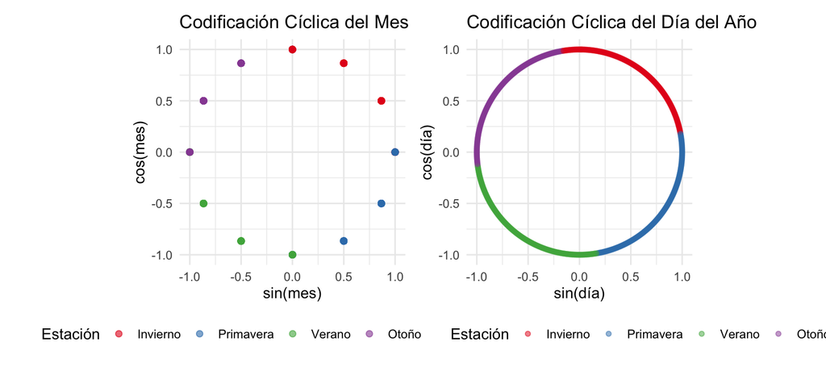

```r
p_mes <- ggplot(df_model, aes(x = mes_sin, y = mes_cos, color = estacion)) +
  geom_point(size = 2, alpha = 0.6) +
  scale_color_brewer(palette = "Set1") +
  coord_equal() +
  labs(title = "Codificación Cíclica del Mes",
       x = "sin(mes)", y = "cos(mes)", color = "Estación") +
  theme_minimal(base_size = 12)

p_dia <- ggplot(df_model, aes(x = dia_anio_sin, y = dia_anio_cos, color = estacion)) +
  geom_point(size = 1.5, alpha = 0.5) +
  scale_color_brewer(palette = "Set1") +
  coord_equal() +
  labs(title = "Codificación Cíclica del Día del Año",
       x = "sin(día)", y = "cos(día)", color = "Estación") +
  theme_minimal(base_size = 12)

p_mes + p_dia + plot_layout(guides = "collect") &
  theme(legend.position = "bottom")
```

La distribución circular confirma que **las estaciones se agrupan en arcos del círculo**, lo cual permite al modelo capturar la periodicidad sin discontinuidades artificiales (como pasar de diciembre = 12 a enero = 1).

## Codificación de variables categóricas

```r
# Variables categóricas presentes
cat_vars <- df_model %>%
  select(where(is.factor)) %>%
  names()

cat("Variables categóricas a codificar:", paste(cat_vars, collapse = ", "), "\n\n")
```

```
## Variables categóricas a codificar: estacion, anio, mes, feriado, dia_semana, dia_laboral, clima
```

```r
# Niveles por variable
for (v in cat_vars) {
  cat(v, "→", nlevels(df_model[[v]]), "niveles:",
      paste(levels(df_model[[v]]), collapse = ", "), "\n")
}
```

```
## estacion → 4 niveles: Invierno, Primavera, Verano, Otoño
## anio → 2 niveles: 2011, 2012
## mes → 12 niveles: Jan, Feb, Mar, Apr, May, Jun, Jul, Aug, Sep, Oct, Nov, Dec
## feriado → 2 niveles: No, Sí
## dia_semana → 7 niveles: Dom, Lun, Mar, Mié, Jue, Vie, Sab
## dia_laboral → 2 niveles: No, Sí
## clima → 4 niveles: Despejado, Nublado, Lluvia Ligera, Tormenta
```

```r
# One-hot encoding con model.matrix (drop first = categoría de referencia)
df_encoded <- df_model %>%
  select(-fecha) %>%                        # fecha ya fue explotada en features
  mutate(across(where(is.factor), as.factor))

dummy_matrix <- model.matrix(~ . - 1, data = df_encoded)

# Convertir a tibble limpio
df_final <- as_tibble(dummy_matrix) %>%
  janitor::clean_names()

cat("\nDimensiones del dataset final (one-hot):",
    nrow(df_final), "filas ×", ncol(df_final), "columnas\n")
```

```
##
## Dimensiones del dataset final (one-hot): 731 filas × 44 columnas
```

```r
df_final %>%
  head(8) %>%
  kable(digits = 3,
        caption = "Primeras 8 filas del dataset codificado (one-hot)") %>%
  kable_styling(bootstrap_options = c("striped", "hover", "condensed"),
                full_width = FALSE, font_size = 11) %>%
  scroll_box(width = "100%")
```

Primeras 8 filas del dataset codificado (one-hot)

| estacion_invierno | estacion_primavera | estacion_verano | estacion_otono | anio2012 | mes_feb | mes_mar | mes_apr | mes_may | mes_jun | mes_jul | mes_aug | mes_sep | mes_oct | mes_nov | mes_dec | feriado_si | dia_semana_lun | dia_semana_mar | dia_semana_mie | dia_semana_jue | dia_semana_vie | dia_semana_sab | dia_laboral_si | clima_nublado | clima_lluvia_ligera | clima_tormenta | temp | atemp | hum | … |
| --- | --- | --- | --- | --- | --- | --- | --- | --- | --- | --- | --- | --- | --- | --- | --- | --- | --- | --- | --- | --- | --- | --- | --- | --- | --- | --- | --- | --- | --- | --- |
| 1 | 0 | 0 | 0 | 0 | 0 | 0 | 0 | 0 | 0 | 0 | 0 | 0 | 0 | 0 | 0 | 0 | 0 | 0 | 0 | 0 | 0 | 1 | 0 | 1 | 0 | 0 | 0.344 | 0.364 | 0.806 | … |
| 1 | 0 | 0 | 0 | 0 | 0 | 0 | 0 | 0 | 0 | 0 | 0 | 0 | 0 | 0 | 0 | 0 | 0 | 0 | 0 | 0 | 0 | 0 | 0 | 1 | 0 | 0 | 0.363 | 0.354 | 0.696 | … |
| 1 | 0 | 0 | 0 | 0 | 0 | 0 | 0 | 0 | 0 | 0 | 0 | 0 | 0 | 0 | 0 | 0 | 1 | 0 | 0 | 0 | 0 | 0 | 1 | 0 | 0 | 0 | 0.196 | 0.189 | 0.437 | … |
| 1 | 0 | 0 | 0 | 0 | 0 | 0 | 0 | 0 | 0 | 0 | 0 | 0 | 0 | 0 | 0 | 0 | 0 | 1 | 0 | 0 | 0 | 0 | 1 | 0 | 0 | 0 | 0.200 | 0.212 | 0.590 | … |
| 1 | 0 | 0 | 0 | 0 | 0 | 0 | 0 | 0 | 0 | 0 | 0 | 0 | 0 | 0 | 0 | 0 | 0 | 0 | 1 | 0 | 0 | 0 | 1 | 0 | 0 | 0 | 0.227 | 0.229 | 0.437 | … |
| 1 | 0 | 0 | 0 | 0 | 0 | 0 | 0 | 0 | 0 | 0 | 0 | 0 | 0 | 0 | 0 | 0 | 0 | 0 | 0 | 1 | 0 | 0 | 1 | 0 | 0 | 0 | 0.204 | 0.233 | 0.518 | … |
| 1 | 0 | 0 | 0 | 0 | 0 | 0 | 0 | 0 | 0 | 0 | 0 | 0 | 0 | 0 | 0 | 0 | 0 | 0 | 0 | 0 | 1 | 0 | 1 | 1 | 0 | 0 | 0.197 | 0.209 | 0.499 | … |
| 1 | 0 | 0 | 0 | 0 | 0 | 0 | 0 | 0 | 0 | 0 | 0 | 0 | 0 | 0 | 0 | 0 | 0 | 0 | 0 | 0 | 0 | 1 | 0 | 1 | 0 | 0 | 0.165 | 0.162 | 0.536 | … |

```r
cat("══════════════════════════════════════════════\n")
```

```
## ══════════════════════════════════════════════
```

```r
cat("  RESUMEN DE PREPARACIÓN DEL DATASET\n")
```

```
##   RESUMEN DE PREPARACIÓN DEL DATASET
```

```r
cat("══════════════════════════════════════════════\n")
```

```
## ══════════════════════════════════════════════
```

```r
cat("  Filas               :", nrow(df_final), "\n")
```

```
##   Filas               : 731
```

```r
cat("  Columnas            :", ncol(df_final), "\n")
```

```
##   Columnas            : 44
```

```r
cat("  Variables numéricas :", sum(sapply(df_final, is.numeric)), "\n")
```

```
##   Variables numéricas : 44
```

```r
cat("  Valores faltantes   :", sum(is.na(df_final)), "\n")
```

```
##   Valores faltantes   : 0
```

```r
cat("══════════════════════════════════════════════\n")
```

```
## ══════════════════════════════════════════════
```

```r
cat("  Dataset listo para modelado predictivo.\n")
```

```
##   Dataset listo para modelado predictivo.
```

#División de entrenamiento /Prueba

```r
set.seed(123)

#Creación de una partición del 70% para el entrenamiento
trainIndex <- createDataPartition(df_final$total_rentas, p = 0.7, list = FALSE)

train <- df_final[trainIndex, ]
test  <- df_final[-trainIndex, ]
```

#Modelo 1 #Este modelo tiene el objectivo hacer una indentificación y cunatificación #Basado en la influencia presente de los factores climaticos y temporales #En la demanda de bicicletas diarias

#Ajuste del modelo

#Que explique el total_rentas #Buscamos aislar el impacto de variables criticas como son el clima #De las varaibles del crecimiento del negocio como lo es el año 2012

```r
modelo_1 <- lm(total_rentas ~ anio2012 +
               temp +
               atemp +
               hum +
               windspeed +
               estacion_primavera +
               estacion_verano +
               estacion_otono +
               clima_nublado +
               clima_lluvia_ligera +
               mes_sin +
               mes_cos,
               data = train)
summary(modelo_1)
```

```
##
## Call:
## lm(formula = total_rentas ~ anio2012 + temp + atemp + hum + windspeed +
##     estacion_primavera + estacion_verano + estacion_otono + clima_nublado +
##     clima_lluvia_ligera + mes_sin + mes_cos, data = train)
##
## Residuals:
##     Min      1Q  Median      3Q     Max
## -3808.1  -379.6   115.1   501.0  3308.7
##
## Coefficients:
##                     Estimate Std. Error t value Pr(>|t|)
## (Intercept)          1737.11     331.41   5.242 2.35e-07 ***
## anio2012             2020.83      76.03  26.579  < 2e-16 ***
## temp                 -937.64    2869.40  -0.327  0.74398
## atemp                6094.72    3107.10   1.962  0.05037 .
## hum                 -1117.27     365.92  -3.053  0.00238 **
## windspeed           -2241.06     538.36  -4.163 3.70e-05 ***
## estacion_primavera    917.81     177.82   5.161 3.54e-07 ***
## estacion_verano       379.17     223.92   1.693  0.09101 .
## estacion_otono       1242.82     178.29   6.971 9.97e-12 ***
## clima_nublado        -422.99      98.93  -4.275 2.28e-05 ***
## clima_lluvia_ligera -1984.94     252.66  -7.856 2.43e-14 ***
## mes_sin              -311.10     121.86  -2.553  0.01098 *
## mes_cos              -267.83     154.88  -1.729  0.08438 .
## ---
## Signif. codes:  0 '***' 0.001 '**' 0.01 '*' 0.05 '.' 0.1 ' ' 1
##
## Residual standard error: 842.9 on 502 degrees of freedom
## Multiple R-squared:  0.8152, Adjusted R-squared:  0.8108
## F-statistic: 184.6 on 12 and 502 DF,  p-value: < 2.2e-16
```

#Evaluacion predictiva del primer modelo

```r
# Realizar las predicciones usando el set de prueba (test)
pred <- predict(modelo_1, test)
RMSE <- sqrt(mean((test$total_rentas - pred)^2))
MAE  <- mean(abs(test$total_rentas - pred))
R2 <- cor(test$total_rentas, pred)^2
```

```r
MAE
```

```
## [1] 603.4571
```

#Si sumamos todas las diferencias entre lo real y lo predich o (sin importar si sobraron o faltaron), el error típico es de 603 bicicletas. Al ser menor que el RMSE, nos confirma que el modelo es bastante estable y no tiene errores “extremos” o muy locos que arruinen el promedio.

```r
R2
```

```
## [1] 0.8247895
```

#Interpretación:

#Es la métrica estrella. El modelo logra explicar el 82.48% de la variabilidad de la demanda en el set de prueba. Que este valor sea tan alto (y cercano al de entrenamiento) confirma que no hay sobreajuste (overfitting) y que el modelo generaliza con éxito.

```r
RMSE
```

```
## [1] 814.3295
```

# Interpretación

#En promedio, el modelo se equivoca por 814 bicicletas. Esto quiere decir que si el modelo predice 4,000 rentas, el valor real probablemente estará entre 3,186 y 4,814. Para un negocio que mueve miles de unidades, un error de 814 es un margen aceptable y manejable.

#Modelo 2

#Objectivo del modelo:

#Haremos una evaluación con un modelo con menos variables (más ahorrativo) #Mantiene la capacidad predictiva del modelo 1, eliminando el ruido estadístico

# En este modelo incluimos solo los “Top Predictors” del Modelo 1:

# - anio2012 (Crecimiento)

# - atemp (Sensación térmica - que fue más relevante que temp)

# - hum y windspeed (Factores climáticos de castigo)

# - clima y estaciones (Contexto ambiental)

```r
modelo_2 <- lm(total_rentas ~ anio2012 +
               atemp +
               hum +
               windspeed +
               estacion_primavera +
               estacion_otono +
               clima_nublado +
               clima_lluvia_ligera,
               data = train)


summary(modelo_2)
```

```
##
## Call:
## lm(formula = total_rentas ~ anio2012 + atemp + hum + windspeed +
##     estacion_primavera + estacion_otono + clima_nublado + clima_lluvia_ligera,
##     data = train)
##
## Residuals:
##     Min      1Q  Median      3Q     Max
## -3512.1  -429.1    84.6   480.6  2770.1
##
## Coefficients:
##                     Estimate Std. Error t value Pr(>|t|)
## (Intercept)          1020.93     265.12   3.851 0.000133 ***
## anio2012             1974.02      76.54  25.789  < 2e-16 ***
## atemp                7306.04     253.31  28.842  < 2e-16 ***
## hum                 -1248.90     359.64  -3.473 0.000559 ***
## windspeed           -2443.65     531.98  -4.593 5.51e-06 ***
## estacion_primavera    627.19      92.81   6.758 3.87e-11 ***
## estacion_otono       1176.44      97.02  12.126  < 2e-16 ***
## clima_nublado        -404.42      99.82  -4.052 5.89e-05 ***
## clima_lluvia_ligera -1873.20     254.80  -7.352 7.92e-13 ***
## ---
## Signif. codes:  0 '***' 0.001 '**' 0.01 '*' 0.05 '.' 0.1 ' ' 1
##
## Residual standard error: 860.6 on 506 degrees of freedom
## Multiple R-squared:  0.8058, Adjusted R-squared:  0.8028
## F-statistic: 262.5 on 8 and 506 DF,  p-value: < 2.2e-16
```

#Evaluación predictiva del segundo modelo

```r
pred_2 <- predict(modelo_2, test)


RMSE2   <- sqrt(mean((test$total_rentas - pred_2)^2))
MAE2    <- mean(abs(test$total_rentas - pred_2))
R2 <- cor(test$total_rentas, pred_2)^2
```

```r
RMSE2
```

```
## [1] 863.4179
```

#Interpretación:

#Pérdida de Precisión: Al quitar variables como los meses (mes_sin, mes_cos) o la temperatura real, el error subió en unas 49 bicicletas. El modelo ahora es un poco menos exacto, pero más simple.

```r
R2
```

```
## [1] 0.8030412
```

#Interpretación:

#El modelo simplificado sigue explicando el 80.30% de la demanda. Es un modelo robusto, pero perdimos un 2.18% de precisión al eliminar variables.

```r
MAE2
```

```
## [1] 640.1152
```

#Interpretación:

#El error absoluto promedio subió en 37 bicicletas. Esto significa que, en un día típico, el Modelo 2 se aleja más de la realidad que el Modelo 1.

#Conclusiones del modelo 2:

Aunque el Modelo 2 cumple con el principio de ahorrativo (usar menos variables para facilitar la interpretación), en este caso específico la simplificación no compensa la pérdida de precisión. En un negocio de logística como Bike Sharing, una diferencia de 814 vs 863 en el RMSE puede significar una gestión de inventario menos eficiente.

# Modelo 3

```r
set.seed(123)

modelo_3 <- rpart(
  total_rentas ~ .,
  data = train,
  method = "anova",
  control = rpart.control(cp = 0.001)
)

summary(modelo_3)
```

```
## Call:
## rpart(formula = total_rentas ~ ., data = train, method = "anova",
##     control = rpart.control(cp = 0.001))
##   n= 515
##
##             CP nsplit rel error    xerror       xstd
## 1  0.407073102      0 1.0000000 1.0026110 0.04775120
## 2  0.217887672      1 0.5929269 0.6262933 0.03330561
## 3  0.065615604      2 0.3750392 0.4097852 0.03406093
## 4  0.037531413      3 0.3094236 0.3552111 0.03117029
## 5  0.027163970      4 0.2718922 0.3099929 0.03040983
## 6  0.019364648      5 0.2447282 0.2957783 0.03002122
## 7  0.016567209      6 0.2253636 0.2816571 0.03100931
## 8  0.012286052      7 0.2087964 0.2713919 0.02528932
## 9  0.011796471      8 0.1965103 0.2742509 0.02640580
## 10 0.008010555      9 0.1847139 0.2671627 0.02650318
## 11 0.006848709     10 0.1767033 0.2543323 0.02663339
## 12 0.006295171     11 0.1698546 0.2496280 0.02638207
## 13 0.005859994     12 0.1635594 0.2475399 0.02633572
## 14 0.005327849     14 0.1518394 0.2439649 0.02644967
## 15 0.005130751     15 0.1465116 0.2427024 0.02644959
## 16 0.004908892     16 0.1413808 0.2385765 0.02630731
## 17 0.004660086     17 0.1364719 0.2349766 0.02581895
## 18 0.003448772     19 0.1271518 0.2260567 0.02560303
## 19 0.003220035     20 0.1237030 0.2235002 0.02504950
## 20 0.002991734     21 0.1204830 0.2215694 0.02505640
## 21 0.002824320     22 0.1174912 0.2188384 0.02465801
## 22 0.002323293     24 0.1118426 0.2170465 0.02443908
## 23 0.001660631     25 0.1095193 0.2123236 0.02440917
## 24 0.001547210     26 0.1078587 0.2103785 0.02408921
## 25 0.001404743     27 0.1063115 0.2093506 0.02408321
## 26 0.001152436     28 0.1049067 0.2108836 0.02413823
## 27 0.001119992     29 0.1037543 0.2128017 0.02415605
## 28 0.001012310     30 0.1026343 0.2124354 0.02415216
## 29 0.001000000     31 0.1016220 0.2123858 0.02413871
##
## Variable importance
##              temp             atemp      dia_anio_cos      dia_del_anio
##                17                17                12                10
##          anio2012           mes_cos estacion_invierno      dia_anio_sin
```

[output cut: 557 more lines]

[output not shown]

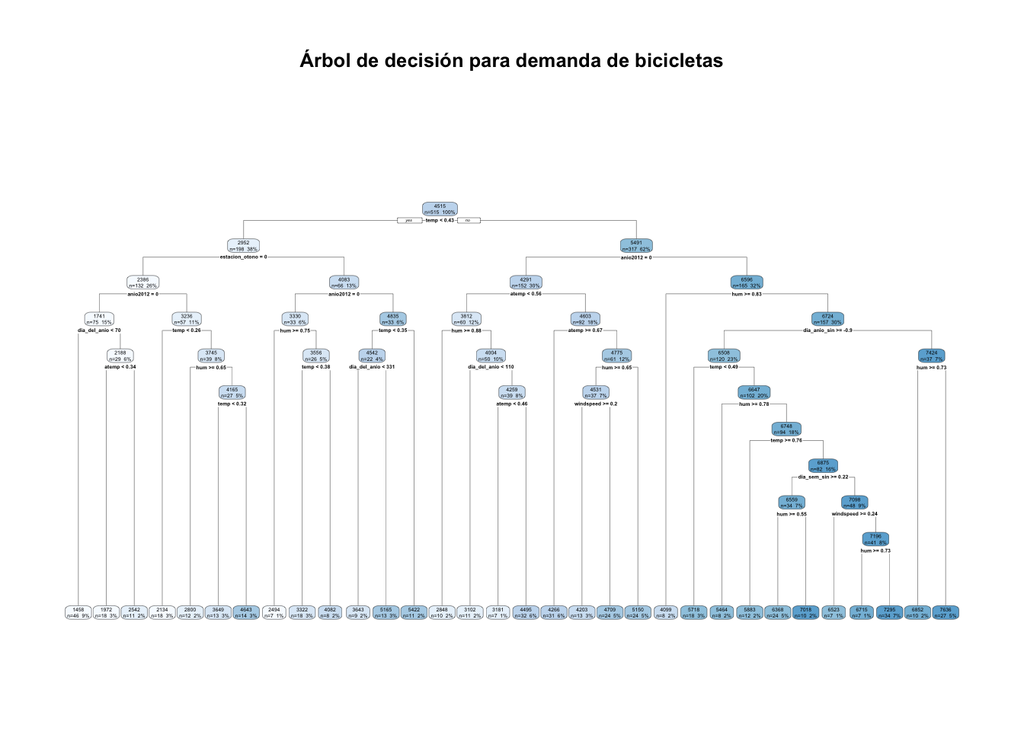

```r
rpart.plot(modelo_3,
           type = 2,
           extra = 101,
           fallen.leaves = TRUE,
           main = "Árbol de decisión para demanda de bicicletas")
```

```r
# Realizar las predicciones usando el set de prueba (test)
pred_3 <- predict(modelo_3, test)

RMSE3 <- sqrt(mean((test$total_rentas - pred_3)^2))
MAE3  <- mean(abs(test$total_rentas - pred_3))
R2_3  <- cor(test$total_rentas, pred_3)^2

RMSE3
```

```
## [1] 918.065
```

```r
MAE3
```

```
## [1] 686.3618
```

```r
R2_3
```

```
## [1] 0.778588
```

```r
comparacion <- tibble(
  Modelo = c("Modelo 1 (Regresión lineal completa)",
             "Modelo 2 (Regresión lineal simplificada)",
             "Modelo 3 (Árbol de decisión)"),

  RMSE = c(RMSE, RMSE2, RMSE3),
  MAE  = c(MAE,  MAE2,  MAE3),
  R2   = c(R2,   R2,    R2_3)
)

comparacion %>%
  kable(digits = 2, caption = "Comparación de desempeño de modelos") %>%
  kable_styling(full_width = FALSE)
```

Comparación de desempeño de modelos

[output not shown]

#Interpretación

#El error absoluto promedio subió 46.24 bicicletas

*Proyecto desarrollado para el curso CD-501 Analítica Predictiva de Datos — Universidad Fidélitas.*